# Guth Data Checking Report

Essie Hengeveld

2026-10-25

# Introduction & Study Background

The research question for this project is, “Do students from racial/ethnic groups that are underrepresented in medicine (URM) have different Objective Structured Clinical Examination (OSCE) scores than those not from under-represented groups?” The clinical hypothesis is that scores will be different between URM and non-URM students.

## Data

Dr. Guth, the primary investigator for this project, provided a cleaned data-set for checking prior to project implementation. This report documents the data-checking process for the provided data-set, which includes data from 199 students from the class of 2020 at the School of Medicine across all disciplines. 52 variables are included in the dataset, including clinical and final course grades, test scores, and limited demographic information. At the time the data were collected, not all students had completed every course, OSCE, or test, resulsting in some missingness for most variables. The data-set includes a constructed variable indicating whether a student belongs to a subgroup considered URM at the School of Medicine, as well as a variable flagging whether someone is URM according to the AAMC.

See table 1 below for all OSCE related-variables included in the provided data-set, stratified by the provided university-level URM indicator.

|  | Non-URM (N=132) | URM (N=60) | Unknown (N=7) | Overall (N=199) |
| --- | --- | --- | --- | --- |
| Gender |  |  |  |  |
| F | 70 (53.0%) | 29 (48.3%) | 2 (28.6%) | 101 (50.8%) |
| M | 62 (47.0%) | 31 (51.7%) | 4 (57.1%) | 97 (48.7%) |
| D | 0 (0%) | 0 (0%) | 1 (14.3%) | 1 (0.5%) |
| P1SprBates_PhysExamScore |  |  |  |  |
| Mean (SD) | 93.4 (5.96) | 92.8 (7.50) | 97.1 (2.08) | 93.3 (6.39) |
| Median [Min, Max] | 94.1 [66.2, 100] | 95.6 [60.3, 100] | 97.1 [94.1, 100] | 95.6 [60.3, 100] |
| Missing | 28 (21.2%) | 13 (21.7%) | 1 (14.3%) | 42 (21.1%) |
| P1SprBates_CommScore |  |  |  |  |
| Mean (SD) | 92.3 (8.09) | 89.7 (9.23) | 95.0 (5.48) | 91.6 (8.44) |
| Median [Min, Max] | 95.0 [60.0, 100] | 90.0 [60.0, 100] | 95.0 [85.0, 100] | 95.0 [60.0, 100] |
| Missing | 28 (21.2%) | 13 (21.7%) | 1 (14.3%) | 42 (21.1%) |
| P1SprBates_MedDocScore |  |  |  |  |
| Mean (SD) | 96.7 (5.82) | 94.1 (9.62) | 89.6 (12.0) | 95.7 (7.56) |
| Median [Min, Max] | 100 [65.0, 100] | 100 [65.0, 100] | 91.3 [72.5, 100] | 100 [65.0, 100] |
| Missing | 28 (21.2%) | 13 (21.7%) | 1 (14.3%) | 42 (21.1%) |
| P1FallBodySys_PhysExamScore |  |  |  |  |
| Mean (SD) | 93.0 (4.22) | 90.8 (7.37) | 95.0 (2.33) | 92.4 (5.34) |
| Median [Min, Max] | 93.5 [79.8, 100] | 93.0 [67.7, 99.1] | 94.7 [92.4, 99.1] | 93.5 [67.7, 100] |
| Missing | 28 (21.2%) | 17 (28.3%) | 1 (14.3%) | 46 (23.1%) |
| P2FallRamos_PhysExamScore |  |  |  |  |
| Mean (SD) | 94.8 (6.86) | 94.7 (4.80) | 98.7 (3.14) | 94.9 (6.24) |
| Median [Min, Max] | 96.2 [61.5, 100] | 96.2 [83.0, 100] | 100 [92.3, 100] | 96.2 [61.5, 100] |
| Missing | 26 (19.7%) | 14 (23.3%) | 1 (14.3%) | 41 (20.6%) |
| P2FallRamos_CommScore |  |  |  |  |
| Mean (SD) | 94.7 (7.71) | 94.7 (7.48) | 97.5 (4.18) | 94.8 (7.53) |
| Median [Min, Max] | 100 [60.0, 100] | 95.0 [60.0, 100] | 100 [90.0, 100] | 100 [60.0, 100] |
| Missing | 26 (19.7%) | 14 (23.3%) | 1 (14.3%) | 41 (20.6%) |
| P2FallRamos_OralPresScore |  |  |  |  |
| Mean (SD) | 96.8 (5.82) | 97.1 (4.66) | 96.7 (5.16) | 96.9 (5.45) |
| Median [Min, Max] | 100 [70.0, 100] | 100 [80.0, 100] | 100 [90.0, 100] | 100 [70.0, 100] |
| Missing | 26 (19.7%) | 14 (23.3%) | 1 (14.3%) | 41 (20.6%) |
| P2FallPayne_PhysExamScore |  |  |  |  |
| Mean (SD) | 88.8 (6.25) | 88.7 (6.42) | 91.3 (3.75) | 88.9 (6.22) |
| Median [Min, Max] | 89.9 [65.9, 98.6] | 89.9 [72.5, 100] | 90.6 [87.7, 97.1] | 89.9 [65.9, 100] |
| Missing | 26 (19.7%) | 14 (23.3%) | 1 (14.3%) | 41 (20.6%) |
| P2FallPayne_CommScore |  |  |  |  |
| Mean (SD) | 93.3 (8.28) | 94.0 (6.82) | 85.7 (10.8) | 93.2 (8.08) |
| Median [Min, Max] | 96.4 [57.1, 100] | 96.4 [64.3, 100] | 85.7 [67.9, 100] | 96.4 [57.1, 100] |
| Missing | 26 (19.7%) | 14 (23.3%) | 1 (14.3%) | 41 (20.6%) |
| P2FallPayne_MedDocScore |  |  |  |  |
| Mean (SD) | 94.4 (6.08) | 91.4 (9.20) | 95.7 (6.98) | 93.5 (7.25) |
| Median [Min, Max] | 96.0 [72.0, 100] | 96.0 [64.0, 100] | 98.0 [82.0, 100] | 96.0 [64.0, 100] |
| Missing | 26 (19.7%) | 14 (23.3%) | 1 (14.3%) | 41 (20.6%) |
| P2SpringHyde_PhysExamScore |  |  |  |  |
| Mean (SD) | 87.2 (7.68) | 81.6 (12.4) | 79.9 (7.99) | 85.3 (9.64) |
| Median [Min, Max] | 87.5 [64.8, 100] | 86.4 [51.1, 98.9] | 77.8 [72.7, 94.3] | 87.5 [51.1, 100] |
| Missing | 26 (19.7%) | 15 (25.0%) | 1 (14.3%) | 42 (21.1%) |
| P2SpringHyde_CommScore |  |  |  |  |
| Mean (SD) | 91.3 (11.0) | 87.6 (13.4) | 77.5 (15.1) | 89.7 (12.2) |
| Median [Min, Max] | 95.0 [50.0, 100] | 90.0 [40.0, 100] | 77.5 [55.0, 100] | 95.0 [40.0, 100] |
| Missing | 26 (19.7%) | 15 (25.0%) | 1 (14.3%) | 42 (21.1%) |
| P2SpringHyde_MedDocScore |  |  |  |  |
| Mean (SD) | 88.7 (9.82) | 87.7 (10.5) | 82.3 (13.3) | 88.2 (10.2) |
| Median [Min, Max] | 90.0 [60.0, 100] | 88.8 [55.0, 100] | 80.0 [65.0, 100] | 90.0 [55.0, 100] |
| Missing | 26 (19.7%) | 15 (25.0%) | 1 (14.3%) | 42 (21.1%) |
| P2SpringSnelling_PhysExamScore |  |  |  |  |
| Mean (SD) | 85.8 (11.4) | 83.8 (13.5) | 88.5 (8.83) | 85.3 (12.0) |
| Median [Min, Max] | 87.7 [42.8, 98.6] | 85.5 [28.3, 98.6] | 90.2 [74.6, 98.6] | 87.7 [28.3, 98.6] |
| Missing | 26 (19.7%) | 15 (25.0%) | 1 (14.3%) | 42 (21.1%) |
| P2SpringSnelling_CommScore |  |  |  |  |
| Mean (SD) | 92.3 (8.87) | 93.1 (7.85) | 95.8 (4.92) | 92.6 (8.46) |
| Median [Min, Max] | 95.0 [65.0, 100] | 95.0 [70.0, 100] | 97.5 [90.0, 100] | 95.0 [65.0, 100] |
| Missing | 26 (19.7%) | 15 (25.0%) | 1 (14.3%) | 42 (21.1%) |
| P2SpringSnelling_MedDocScore |  |  |  |  |
| Mean (SD) | 90.0 (10.4) | 88.5 (8.81) | 89.0 (8.02) | 89.6 (9.85) |
| Median [Min, Max] | 95.0 [47.5, 100] | 90.0 [67.5, 100] | 85.0 [82.5, 100] | 92.5 [47.5, 100] |
| Missing | 39 (29.5%) | 24 (40.0%) | 2 (28.6%) | 65 (32.7%) |

To see a table 1 for all 52 variables provided in the dataset, click below:

**Table 1: Full Descriptive Statistics**

| **Characteristic** | **Non-URM** N = 132<sup>1</sup> | **URM** N = 60<sup>1</sup> | **Unknown** N = 7<sup>1</sup> |
| --- | --- | --- | --- |
| ResearchID | 105,324 (103,681, 107,599) | 105,625 (103,852, 107,709) | 105,604 (104,075, 107,540) |
| AAC_clinical_grade |  |  |  |
| Fail | 0 (0%) | 0 (0%) | 0 (NA%) |
| Pass | 2 (17%) | 3 (43%) | 0 (NA%) |
| High Pass | 7 (58%) | 1 (14%) | 0 (NA%) |
| Honors | 3 (25%) | 3 (43%) | 0 (NA%) |
| Pass with remediation | 0 (0%) | 0 (0%) | 0 (NA%) |
| Unknown | 120 | 53 | 7 |
| CPC_clinical_grade |  |  |  |
| Fail | 0 (0%) | 0 (0%) | 0 (0%) |
| Pass | 10 (11%) | 4 (12%) | 3 (43%) |
| High Pass | 31 (33%) | 12 (36%) | 2 (29%) |
| Honors | 52 (56%) | 17 (52%) | 2 (29%) |
| Pass with remediation | 0 (0%) | 0 (0%) | 0 (0%) |
| Unknown | 39 | 27 | 0 |
| HAC_clinical_grade |  |  |  |
| Fail | 0 (0%) | 0 (0%) | 0 (0%) |
| Pass | 25 (21%) | 16 (31%) | 0 (0%) |
| High Pass | 35 (29%) | 24 (47%) | 3 (50%) |
| Honors | 59 (50%) | 11 (22%) | 3 (50%) |
| Pass with remediation | 0 (0%) | 0 (0%) | 0 (0%) |
| Unknown | 13 | 9 | 1 |
| ICAC_clinical_grade |  |  |  |
| Fail | 0 (0%) | 0 (0%) | 0 (0%) |
| Pass | 24 (22%) | 15 (27%) | 1 (20%) |
| High Pass | 40 (36%) | 25 (45%) | 2 (40%) |
| Honors | 47 (42%) | 15 (27%) | 2 (40%) |
| Pass with remediation | 0 (0%) | 0 (0%) | 0 (0%) |
| Unknown | 21 | 5 | 2 |
| NC_clinical_grade |  |  |  |

[output cut: 232 more lines]

<sup>1</sup> Median (Q1, Q3); n (%)

# Variable Examination

We examined relevant variables using both tables and plots, a selection of which are shared in this report.

## OSCE Scores

The outcome variables for this analysis are the OSCE scores. There are 16 different OSCE scores provided within this dataset. Most include several scores for the same interaction. Missingness for each score ranges from 41-65 observations, which is a significant missing rate for each score, and will need to be addressed in the analysis plan. A total of 39 students were missing all 16 OSCE scores, and will need to be excluded from the analysis, bringing the total sample down to 160. Participants with all OSCE scores missing vary by race (including URM status), gender, class scores and test scores. After excluding those with all OSCE scores missing, the remaining missingness within the OSCE scores ranges from 2-26. These leaves an analytical sample of 160.

**“Click here for table 1 after removal of students with no OSCE scores and table 1 for removed students”**

```r
OSCE_only_reduced <- table1(~
       gender +
       P1SprBates_PhysExamScore +
       P1SprBates_CommScore+
       P1SprBates_MedDocScore+
       P1FallBodySys_PhysExamScore+
       P2FallRamos_PhysExamScore+
       P2FallRamos_CommScore+
       P2FallRamos_OralPresScore+
       P2FallPayne_PhysExamScore+
       P2FallPayne_CommScore+
       P2FallPayne_MedDocScore+
       P2SpringHyde_PhysExamScore+
       P2SpringHyde_CommScore+
       P2SpringHyde_MedDocScore+
       P2SpringSnelling_PhysExamScore+
       P2SpringSnelling_CommScore+
       P2SpringSnelling_MedDocScore
       |URM, data = df_reduced)

##Call the table
OSCE_only_reduced
```

|  | Non-URM (N=106) | URM (N=48) | Unknown (N=6) | Overall (N=160) |
| --- | --- | --- | --- | --- |
| Gender |  |  |  |  |
| F | 56 (52.8%) | 22 (45.8%) | 2 (33.3%) | 80 (50.0%) |
| M | 50 (47.2%) | 26 (54.2%) | 3 (50.0%) | 79 (49.4%) |
| D | 0 (0%) | 0 (0%) | 1 (16.7%) | 1 (0.6%) |
| P1SprBates_PhysExamScore |  |  |  |  |
| Mean (SD) | 93.4 (5.96) | 92.8 (7.50) | 97.1 (2.08) | 93.3 (6.39) |
| Median [Min, Max] | 94.1 [66.2, 100] | 95.6 [60.3, 100] | 97.1 [94.1, 100] | 95.6 [60.3, 100] |
| Missing | 2 (1.9%) | 1 (2.1%) | 0 (0%) | 3 (1.9%) |
| P1SprBates_CommScore |  |  |  |  |
| Mean (SD) | 92.3 (8.09) | 89.7 (9.23) | 95.0 (5.48) | 91.6 (8.44) |
| Median [Min, Max] | 95.0 [60.0, 100] | 90.0 [60.0, 100] | 95.0 [85.0, 100] | 95.0 [60.0, 100] |
| Missing | 2 (1.9%) | 1 (2.1%) | 0 (0%) | 3 (1.9%) |
| P1SprBates_MedDocScore |  |  |  |  |
| Mean (SD) | 96.7 (5.82) | 94.1 (9.62) | 89.6 (12.0) | 95.7 (7.56) |
| Median [Min, Max] | 100 [65.0, 100] | 100 [65.0, 100] | 91.3 [72.5, 100] | 100 [65.0, 100] |
| Missing | 2 (1.9%) | 1 (2.1%) | 0 (0%) | 3 (1.9%) |
| P1FallBodySys_PhysExamScore |  |  |  |  |
| Mean (SD) | 93.0 (4.22) | 90.8 (7.37) | 95.0 (2.33) | 92.4 (5.34) |
| Median [Min, Max] | 93.5 [79.8, 100] | 93.0 [67.7, 99.1] | 94.7 [92.4, 99.1] | 93.5 [67.7, 100] |
| Missing | 2 (1.9%) | 5 (10.4%) | 0 (0%) | 7 (4.4%) |
| P2FallRamos_PhysExamScore |  |  |  |  |
| Mean (SD) | 94.8 (6.86) | 94.7 (4.80) | 98.7 (3.14) | 94.9 (6.24) |
| Median [Min, Max] | 96.2 [61.5, 100] | 96.2 [83.0, 100] | 100 [92.3, 100] | 96.2 [61.5, 100] |
| Missing | 0 (0%) | 2 (4.2%) | 0 (0%) | 2 (1.3%) |
| P2FallRamos_CommScore |  |  |  |  |
| Mean (SD) | 94.7 (7.71) | 94.7 (7.48) | 97.5 (4.18) | 94.8 (7.53) |
| Median [Min, Max] | 100 [60.0, 100] | 95.0 [60.0, 100] | 100 [90.0, 100] | 100 [60.0, 100] |
| Missing | 0 (0%) | 2 (4.2%) | 0 (0%) | 2 (1.3%) |
| P2FallRamos_OralPresScore |  |  |  |  |
| Mean (SD) | 96.8 (5.82) | 97.1 (4.66) | 96.7 (5.16) | 96.9 (5.45) |
| Median [Min, Max] | 100 [70.0, 100] | 100 [80.0, 100] | 100 [90.0, 100] | 100 [70.0, 100] |
| Missing | 0 (0%) | 2 (4.2%) | 0 (0%) | 2 (1.3%) |
| P2FallPayne_PhysExamScore |  |  |  |  |
| Mean (SD) | 88.8 (6.25) | 88.7 (6.42) | 91.3 (3.75) | 88.9 (6.22) |
| Median [Min, Max] | 89.9 [65.9, 98.6] | 89.9 [72.5, 100] | 90.6 [87.7, 97.1] | 89.9 [65.9, 100] |
| Missing | 0 (0%) | 2 (4.2%) | 0 (0%) | 2 (1.3%) |
| P2FallPayne_CommScore |  |  |  |  |
| Mean (SD) | 93.3 (8.28) | 94.0 (6.82) | 85.7 (10.8) | 93.2 (8.08) |
| Median [Min, Max] | 96.4 [57.1, 100] | 96.4 [64.3, 100] | 85.7 [67.9, 100] | 96.4 [57.1, 100] |
| Missing | 0 (0%) | 2 (4.2%) | 0 (0%) | 2 (1.3%) |
| P2FallPayne_MedDocScore |  |  |  |  |
| Mean (SD) | 94.4 (6.08) | 91.4 (9.20) | 95.7 (6.98) | 93.5 (7.25) |
| Median [Min, Max] | 96.0 [72.0, 100] | 96.0 [64.0, 100] | 98.0 [82.0, 100] | 96.0 [64.0, 100] |
| Missing | 0 (0%) | 2 (4.2%) | 0 (0%) | 2 (1.3%) |
| P2SpringHyde_PhysExamScore |  |  |  |  |
| Mean (SD) | 87.2 (7.68) | 81.6 (12.4) | 79.9 (7.99) | 85.3 (9.64) |
| Median [Min, Max] | 87.5 [64.8, 100] | 86.4 [51.1, 98.9] | 77.8 [72.7, 94.3] | 87.5 [51.1, 100] |
| Missing | 0 (0%) | 3 (6.3%) | 0 (0%) | 3 (1.9%) |
| P2SpringHyde_CommScore |  |  |  |  |
| Mean (SD) | 91.3 (11.0) | 87.6 (13.4) | 77.5 (15.1) | 89.7 (12.2) |
| Median [Min, Max] | 95.0 [50.0, 100] | 90.0 [40.0, 100] | 77.5 [55.0, 100] | 95.0 [40.0, 100] |
| Missing | 0 (0%) | 3 (6.3%) | 0 (0%) | 3 (1.9%) |
| P2SpringHyde_MedDocScore |  |  |  |  |
| Mean (SD) | 88.7 (9.82) | 87.7 (10.5) | 82.3 (13.3) | 88.2 (10.2) |
| Median [Min, Max] | 90.0 [60.0, 100] | 88.8 [55.0, 100] | 80.0 [65.0, 100] | 90.0 [55.0, 100] |
| Missing | 0 (0%) | 3 (6.3%) | 0 (0%) | 3 (1.9%) |
| P2SpringSnelling_PhysExamScore |  |  |  |  |
| Mean (SD) | 85.8 (11.4) | 83.8 (13.5) | 88.5 (8.83) | 85.3 (12.0) |
| Median [Min, Max] | 87.7 [42.8, 98.6] | 85.5 [28.3, 98.6] | 90.2 [74.6, 98.6] | 87.7 [28.3, 98.6] |
| Missing | 0 (0%) | 3 (6.3%) | 0 (0%) | 3 (1.9%) |
| P2SpringSnelling_CommScore |  |  |  |  |
| Mean (SD) | 92.3 (8.87) | 93.1 (7.85) | 95.8 (4.92) | 92.6 (8.46) |
| Median [Min, Max] | 95.0 [65.0, 100] | 95.0 [70.0, 100] | 97.5 [90.0, 100] | 95.0 [65.0, 100] |
| Missing | 0 (0%) | 3 (6.3%) | 0 (0%) | 3 (1.9%) |
| P2SpringSnelling_MedDocScore |  |  |  |  |
| Mean (SD) | 90.0 (10.4) | 88.5 (8.81) | 89.0 (8.02) | 89.6 (9.85) |
| Median [Min, Max] | 95.0 [47.5, 100] | 90.0 [67.5, 100] | 85.0 [82.5, 100] | 92.5 [47.5, 100] |
| Missing | 13 (12.3%) | 12 (25.0%) | 1 (16.7%) | 26 (16.3%) |

```r
tbl_summary(df_missing,
            by = URM)
```

| **Characteristic** | **Non-URM** N = 26<sup>1</sup> | **URM** N = 12<sup>1</sup> | **Unknown** N = 1<sup>1</sup> |
| --- | --- | --- | --- |
| ResearchID | 104,574 (103,962, 108,849) | 104,483 (103,084, 109,216) | 103,694 (103,694, 103,694) |
| AAC_clinical_grade |  |  |  |
| Fail | 0 (0%) | 0 (0%) | 0 (NA%) |
| Pass | 2 (17%) | 3 (43%) | 0 (NA%) |
| High Pass | 7 (58%) | 1 (14%) | 0 (NA%) |
| Honors | 3 (25%) | 3 (43%) | 0 (NA%) |
| Pass with remediation | 0 (0%) | 0 (0%) | 0 (NA%) |
| Unknown | 14 | 5 | 1 |
| CPC_clinical_grade |  |  |  |
| Fail | 0 (0%) | 0 (0%) | 0 (0%) |
| Pass | 1 (7.7%) | 1 (33%) | 0 (0%) |
| High Pass | 7 (54%) | 1 (33%) | 0 (0%) |
| Honors | 5 (38%) | 1 (33%) | 1 (100%) |
| Pass with remediation | 0 (0%) | 0 (0%) | 0 (0%) |
| Unknown | 13 | 9 | 0 |
| HAC_clinical_grade |  |  |  |
| Fail | 0 (0%) | 0 (0%) | 0 (0%) |
| Pass | 7 (28%) | 2 (18%) | 0 (0%) |
| High Pass | 7 (28%) | 7 (64%) | 0 (0%) |
| Honors | 11 (44%) | 2 (18%) | 1 (100%) |
| Pass with remediation | 0 (0%) | 0 (0%) | 0 (0%) |
| Unknown | 1 | 1 | 0 |
| ICAC_clinical_grade |  |  |  |
| Fail | 0 (0%) | 0 (0%) | 0 (0%) |
| Pass | 10 (42%) | 2 (17%) | 1 (100%) |
| High Pass | 5 (21%) | 7 (58%) | 0 (0%) |
| Honors | 9 (38%) | 3 (25%) | 0 (0%) |
| Pass with remediation | 0 (0%) | 0 (0%) | 0 (0%) |
| Unknown | 2 | 0 | 0 |
| NC_clinical_grade |  |  |  |

[output cut: 206 more lines]

<sup>1</sup> Median (Q1, Q3); n (%)

Each score was visualized using a histogram, revealing that all 16 scores show a strong left-skew, as shown in the example plot below:

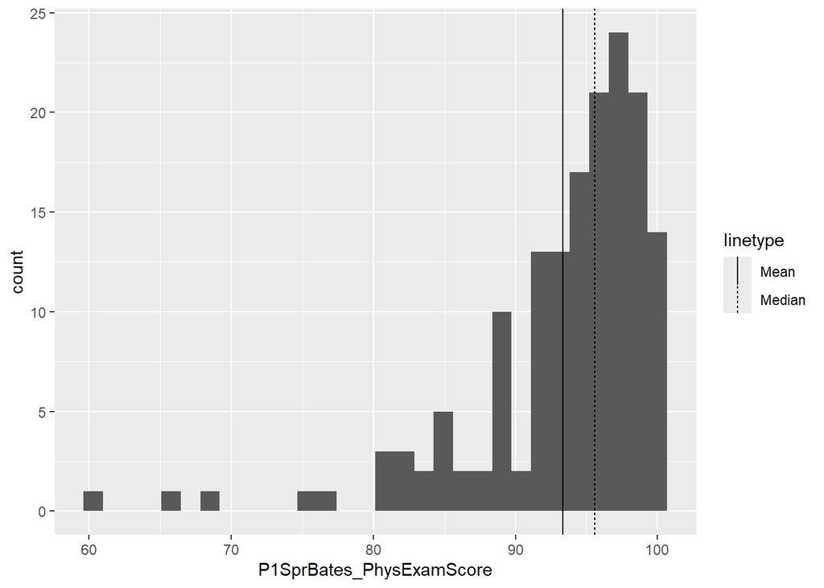

It was also observed that some of the OSCE scores have values including decimal points (eg: 98.53), while others only have values that are multiples of 5, as shown below:

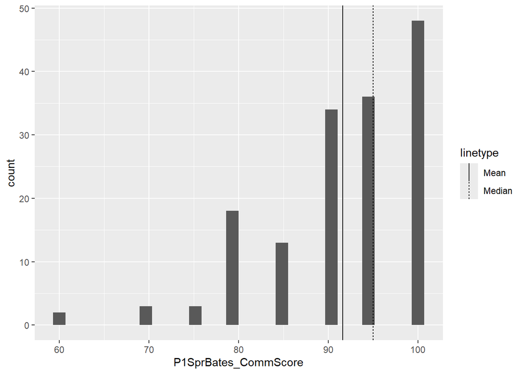

The strong left-skew indicates a need to reflect or transform the data before using any statistical tests requiring a normal distribution. Alternatively, non-parametric tests may be used for analysis.

### OSCE Scores Stratified by URM Status

Box plots were used to visualize the differences in all OSCE scores by URM status. Three sample box plots are included below:

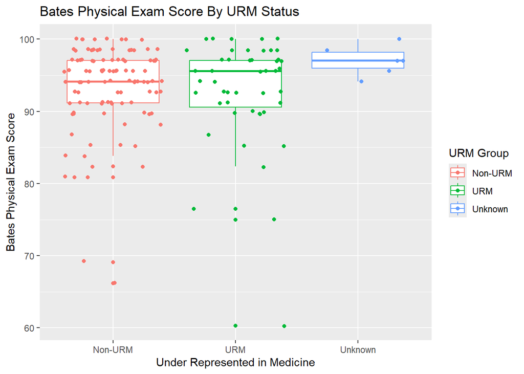

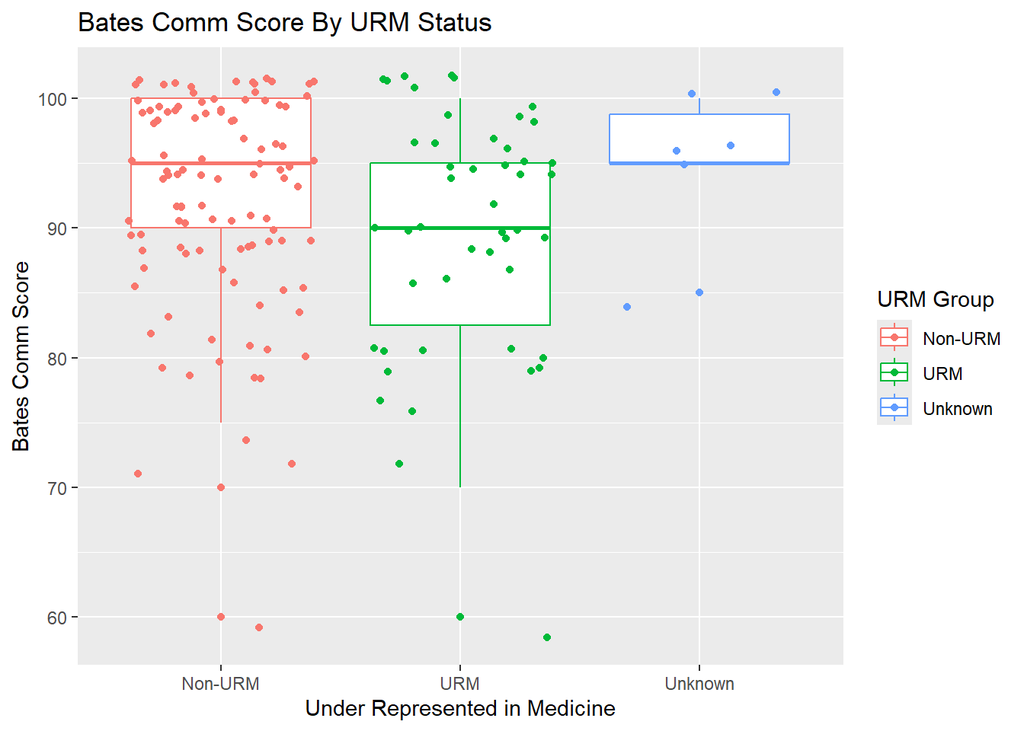

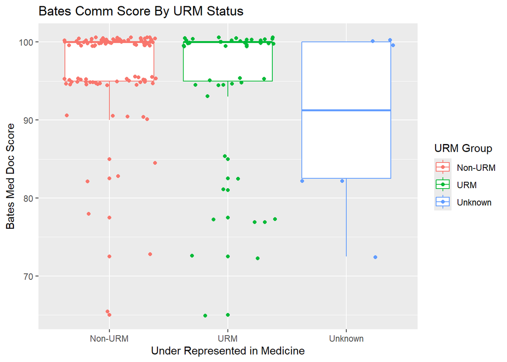

These plots show that in both URM and non-URM groups, the majority of scores are gathered at the top of range.

## URM Variables

Whether an individual is part of a group that is considered URM is the primary explanatory variable for this study. The provided dataset included two constructed variables that identified whether an individual was a member of a racial group that is URM. For this analysis, “URM” uses the University supplied definition which is any self-identification of having a race/ethnicity of AI/AN, Hispanic, Vietnamese, Black/African American or Native Hawaiian. URM_aamc uses a more restrictive definition, which does not include Vietnamese. These two categories overlap, but not perfectly:

```
##
##           Non-URiM URiM Unknown
##   Non-URM      132    0       0
##   URM            8   52       0
##   Unknown        0    0       7
```

For analysis, we intend to use the University supplied definition, as it includes more students who are under-represented at the School of Medicine, which may impact their experience of bias.

## Other Possible Covariates

The rest of the dataset includes exam scores and both final and clinical course grades.

### Final Course Grades

Per the PI, the final course grades are more relevant for this analysis than clinical course grades. Final course grades are divided into five categories: “Fail”, “Pass with remediation”, Pass”, “High Pass”, and “Honors”. Final course grades were examined visually using bar charts, three samples of which are included below. The scores for each course appeared to follow one of three patterns: an approximately even distribution between pass, high pass, honors with some missing data; more than half missing, or all/almost all with a single score. See the samples below.

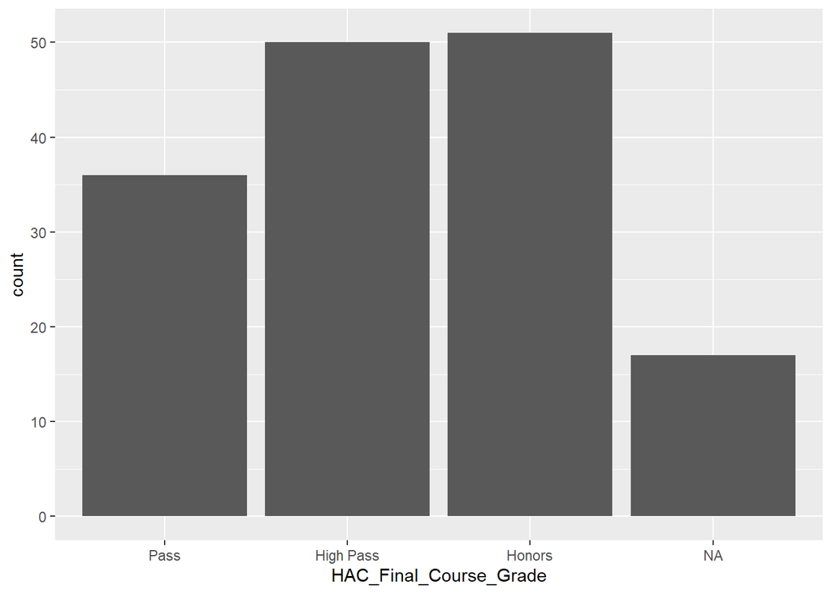

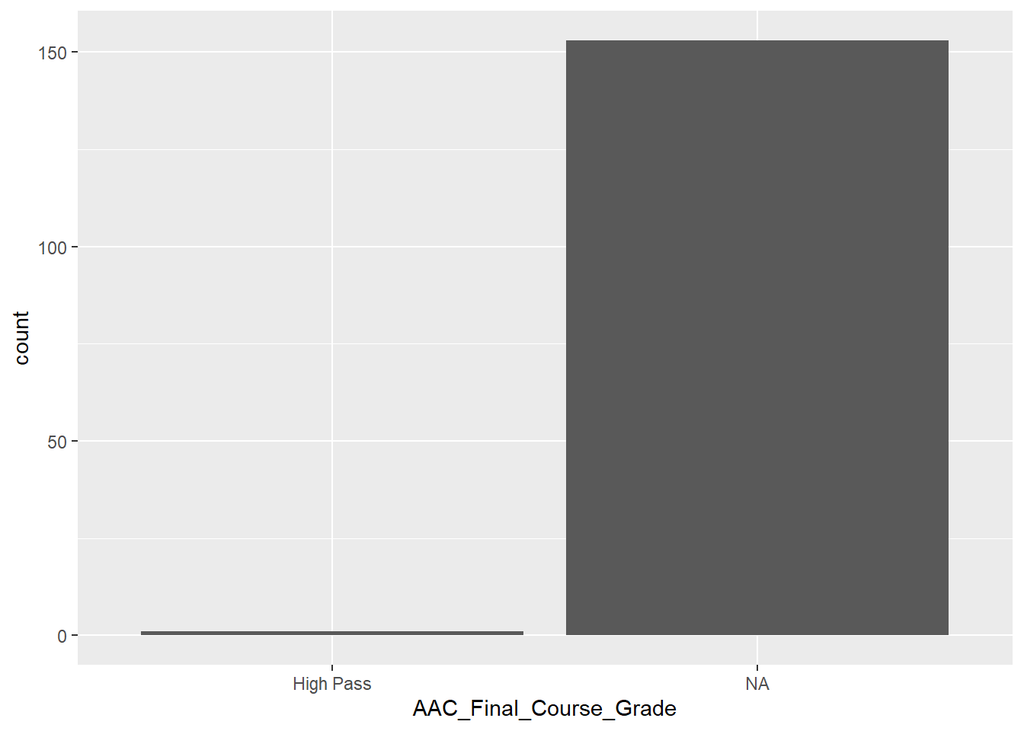

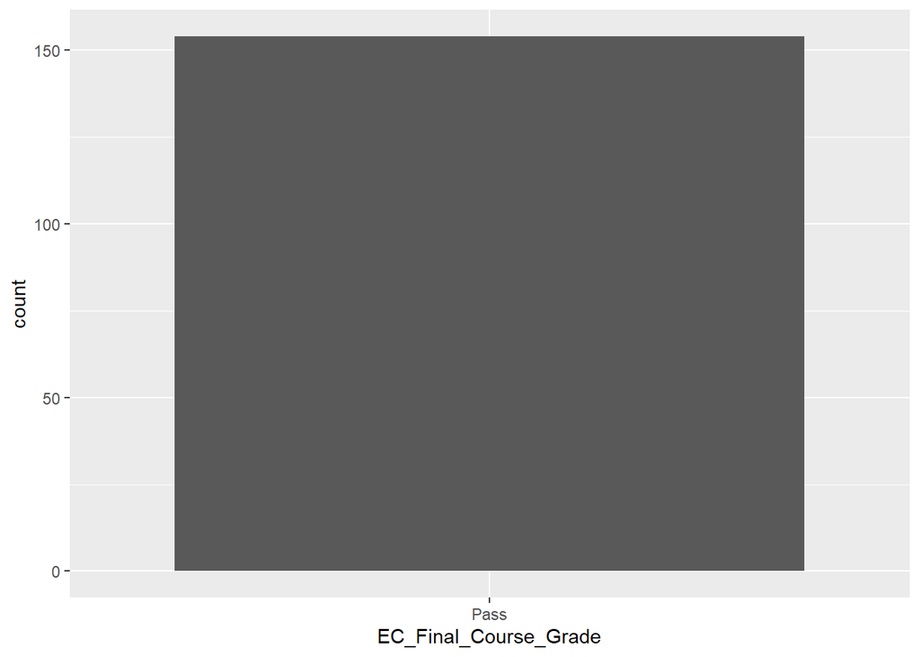

Of the final course grades, the CPC, HAC, ICAC, OBG, OPC and PC final course grades have enough data and enough variation to possibly be useful covariates. However the PI has indicated that temporality cannot be established between grades and the OSCE scores, indicating that these would not be helpful covariates to include in this analysis.

AAC_Final has more than 150 missing values in the original data-set. EC_Final and MSK_Final are almost all pass, therefore are not likely to be useful covariates. There are very few fail/pass with remediation scores across all final grades.

### STEP1 and STEP2 Exam Scores

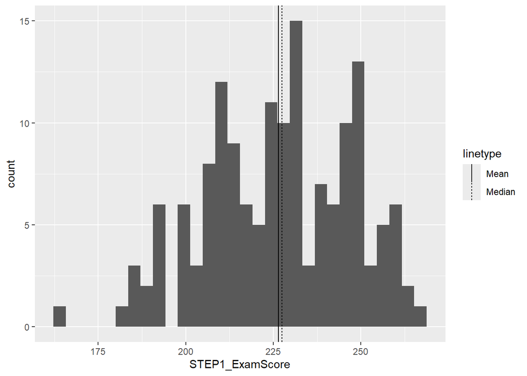

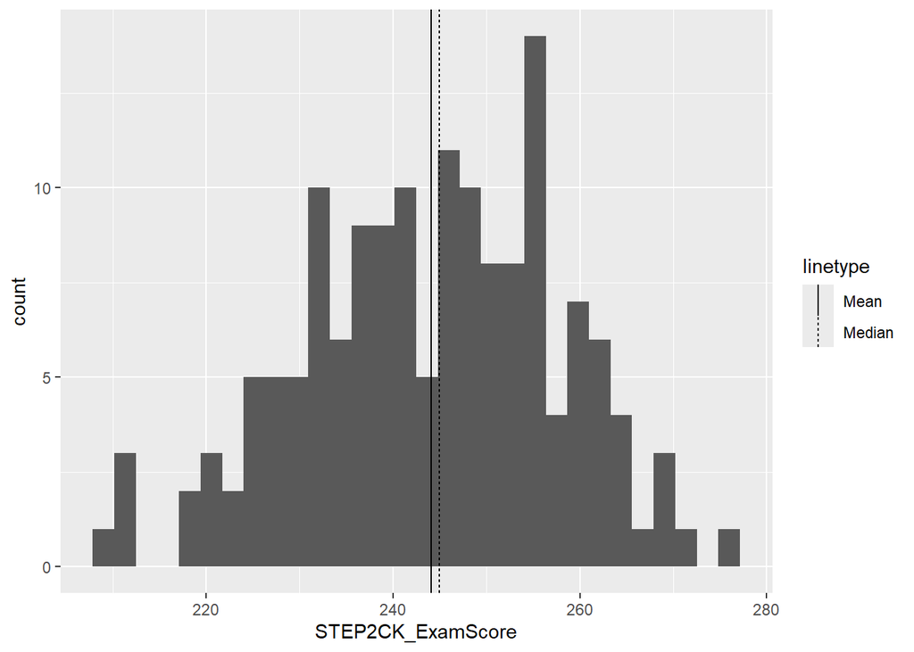

STEP scores will not be included in the analysis, as we cannot establish temporality between the exam scores and the OSCE scores, per the PI.

The final table 1 is below:

|  | Non-URM (N=106) | URM (N=48) | Overall (N=154) |
| --- | --- | --- | --- |
| Gender |  |  |  |
| F | 56 (52.8%) | 22 (45.8%) | 78 (50.6%) |
| M | 50 (47.2%) | 26 (54.2%) | 76 (49.4%) |
| P1SprBates_PhysExamScore |  |  |  |
| Mean (SD) | 93.4 (5.96) | 92.8 (7.50) | 93.2 (6.46) |
| Median [Min, Max] | 94.1 [66.2, 100] | 95.6 [60.3, 100] | 94.1 [60.3, 100] |
| Missing | 2 (1.9%) | 1 (2.1%) | 3 (1.9%) |
| P1SprBates_CommScore |  |  |  |
| Mean (SD) | 92.3 (8.09) | 89.7 (9.23) | 91.5 (8.52) |
| Median [Min, Max] | 95.0 [60.0, 100] | 90.0 [60.0, 100] | 95.0 [60.0, 100] |
| Missing | 2 (1.9%) | 1 (2.1%) | 3 (1.9%) |
| P1SprBates_MedDocScore |  |  |  |
| Mean (SD) | 96.7 (5.82) | 94.1 (9.62) | 95.9 (7.29) |
| Median [Min, Max] | 100 [65.0, 100] | 100 [65.0, 100] | 100 [65.0, 100] |
| Missing | 2 (1.9%) | 1 (2.1%) | 3 (1.9%) |
| P1FallBodySys_PhysExamScore |  |  |  |
| Mean (SD) | 93.0 (4.22) | 90.8 (7.37) | 92.3 (5.40) |
| Median [Min, Max] | 93.5 [79.8, 100] | 93.0 [67.7, 99.1] | 93.2 [67.7, 100] |
| Missing | 2 (1.9%) | 5 (10.4%) | 7 (4.5%) |
| P2FallRamos_PhysExamScore |  |  |  |
| Mean (SD) | 94.8 (6.86) | 94.7 (4.80) | 94.8 (6.29) |
| Median [Min, Max] | 96.2 [61.5, 100] | 96.2 [83.0, 100] | 96.2 [61.5, 100] |
| Missing | 0 (0%) | 2 (4.2%) | 2 (1.3%) |
| P2FallRamos_CommScore |  |  |  |
| Mean (SD) | 94.7 (7.71) | 94.7 (7.48) | 94.7 (7.62) |
| Median [Min, Max] | 100 [60.0, 100] | 95.0 [60.0, 100] | 100 [60.0, 100] |
| Missing | 0 (0%) | 2 (4.2%) | 2 (1.3%) |
| P2FallRamos_OralPresScore |  |  |  |
| Mean (SD) | 96.8 (5.82) | 97.1 (4.66) | 96.9 (5.48) |
| Median [Min, Max] | 100 [70.0, 100] | 100 [80.0, 100] | 100 [70.0, 100] |
| Missing | 0 (0%) | 2 (4.2%) | 2 (1.3%) |
| P2FallPayne_PhysExamScore |  |  |  |
| Mean (SD) | 88.8 (6.25) | 88.7 (6.42) | 88.8 (6.28) |
| Median [Min, Max] | 89.9 [65.9, 98.6] | 89.9 [72.5, 100] | 89.9 [65.9, 100] |
| Missing | 0 (0%) | 2 (4.2%) | 2 (1.3%) |
| P2FallPayne_CommScore |  |  |  |
| Mean (SD) | 93.3 (8.28) | 94.0 (6.82) | 93.5 (7.85) |
| Median [Min, Max] | 96.4 [57.1, 100] | 96.4 [64.3, 100] | 96.4 [57.1, 100] |
| Missing | 0 (0%) | 2 (4.2%) | 2 (1.3%) |
| P2FallPayne_MedDocScore |  |  |  |
| Mean (SD) | 94.4 (6.08) | 91.4 (9.20) | 93.5 (7.27) |
| Median [Min, Max] | 96.0 [72.0, 100] | 96.0 [64.0, 100] | 96.0 [64.0, 100] |
| Missing | 0 (0%) | 2 (4.2%) | 2 (1.3%) |
| P2SpringHyde_PhysExamScore |  |  |  |
| Mean (SD) | 87.2 (7.68) | 81.6 (12.4) | 85.6 (9.66) |
| Median [Min, Max] | 87.5 [64.8, 100] | 86.4 [51.1, 98.9] | 87.5 [51.1, 100] |
| Missing | 0 (0%) | 3 (6.3%) | 3 (1.9%) |
| P2SpringHyde_CommScore |  |  |  |
| Mean (SD) | 91.3 (11.0) | 87.6 (13.4) | 90.2 (11.8) |
| Median [Min, Max] | 95.0 [50.0, 100] | 90.0 [40.0, 100] | 95.0 [40.0, 100] |
| Missing | 0 (0%) | 3 (6.3%) | 3 (1.9%) |
| P2SpringHyde_MedDocScore |  |  |  |
| Mean (SD) | 88.7 (9.82) | 87.7 (10.5) | 88.4 (9.99) |
| Median [Min, Max] | 90.0 [60.0, 100] | 88.8 [55.0, 100] | 90.0 [55.0, 100] |
| Missing | 0 (0%) | 3 (6.3%) | 3 (1.9%) |
| P2SpringSnelling_PhysExamScore |  |  |  |
| Mean (SD) | 85.8 (11.4) | 83.8 (13.5) | 85.2 (12.1) |
| Median [Min, Max] | 87.7 [42.8, 98.6] | 85.5 [28.3, 98.6] | 87.7 [28.3, 98.6] |
| Missing | 0 (0%) | 3 (6.3%) | 3 (1.9%) |
| P2SpringSnelling_CommScore |  |  |  |
| Mean (SD) | 92.3 (8.87) | 93.1 (7.85) | 92.5 (8.56) |
| Median [Min, Max] | 95.0 [65.0, 100] | 95.0 [70.0, 100] | 95.0 [65.0, 100] |
| Missing | 0 (0%) | 3 (6.3%) | 3 (1.9%) |
| P2SpringSnelling_MedDocScore |  |  |  |
| Mean (SD) | 90.0 (10.4) | 88.5 (8.81) | 89.6 (9.94) |
| Median [Min, Max] | 95.0 [47.5, 100] | 90.0 [67.5, 100] | 95.0 [47.5, 100] |
| Missing | 13 (12.3%) | 12 (25.0%) | 25 (16.2%) |

# Questions for the Primary Investigator

Q1. We observed that some OSCE scores are only multiples of 5, while others extend to the hundredths place (eg: 98.53). While this isn’t a problem for analysis, it might signal an error with the scores, if they are both supposed to be formatted similarly. Is this difference in score values a cause for concern?

PI Answer: No further info is available. Assume scores are correct.

Note: No changes or adjustments made

Q2. For the 7-8 students whose URM status is currently categorized as “Unknown”, do you have a preference for how these “Unknowns” are handled? It is a small enough group that it should not be included as a seperate sub-group for analysis, and should be either recoded as URM/non-URM or removed from the data-set.

PI Answer: It is a small enough group that it should not be included as a seperate sub-group for analysis, and should be either recoded as URM/non-URM or removed from the data-set.

Note: These have been dropped accordingly, leaving an analytical sample of 154. See variable exploration: URM section above.

Q3. Some gender identities are mentioned as being URM. Do we want to explore these in our analysis? If we want to explore the distinction between male/female, we have the data to do that. There are only a few “D” values included in the data.

PI Answer: These are all the data we have. Too few here. Great discussion point to consider.

Note: Will explore male/female score differences as a secondary analysis. Included in SOW.

Q4. There are some final grades that have enough variability to be useful as possible covariates. What would we expect the relationship between final course grades and OSCE scores to be? There are very few fail or pass with remediation options, so we would need to explore the distinctions between pass, high pass, and honors. How are these differentiated?

PI Answer: No additional information is available. consider timing of scores vs final grade…does it make sense to use grades as a covariate? what would interpretation be?

Note: The PI pointed out that the timing of scores versus the final grades would be difficult to interpret. Will not use grades as a covariate at this time. SOW has been adjusted to remove grades as a possible covaraite.

Q5. The STEP1 and STEP2 exam scores are more normally distributed with minimal missingness. These might be able to function as covariates in a model. However, only a very small proportion of the sample failed. What might we expect the relationship between the STEP exam scores and the OSCE scores to be?

PI Answer: Same issue with temporarily as above. your concern about limited “fails” is valid..so, will this be informative?

Note: STEP exam scores will not be included as a covariate. SOW has been adjusted accordingly.